# RR_Project2

MERS

8/6/2020

# Impact of Severe Weather Events on Public Health and Economy in the United States

## Synopsis

Here I am presenting the second assignment course project from the Reproducible Research Course. The basic goal of this assignment is to explore the NOAA Storm Database and answer some basic questions about severe weather events. You must use the database to answer the questions below and show the code for your entire analysis. Your analysis can consist of tables, figures, or other summaries. You may use any R package you want to support your analysis.

### Questions

Your data analysis must address the following questions:

#### 1 Across the United States, which types of events (as indicated in the EVTYPE variable) are most harmful with respect to population health?

#### 2 Across the United States, which types of events have the greatest economic consequences?

### Loading libraries

```r
library(ggplot2)
library(dplyr)
#library(plyr)
library(R.utils)
```

## Data processing

```r
filename <- "repdata_data_StormData.csv.bz2"

URL <- "https://d396qusza40orc.cloudfront.net/repdata%2Fdata%2FStormData.csv.bz2"
download.file(URL, filename, method="curl")

stormdata<-read.csv(bzfile(filename))
```

## Exploratory data

First, the data is analyzed to understand the dimension and structure.

```r
# review to the data structure
head(stormdata)
```

```
##   STATE__           BGN_DATE BGN_TIME TIME_ZONE COUNTY COUNTYNAME STATE  EVTYPE
## 1       1  4/18/1950 0:00:00     0130       CST     97     MOBILE    AL TORNADO
## 2       1  4/18/1950 0:00:00     0145       CST      3    BALDWIN    AL TORNADO
## 3       1  2/20/1951 0:00:00     1600       CST     57    FAYETTE    AL TORNADO
## 4       1   6/8/1951 0:00:00     0900       CST     89    MADISON    AL TORNADO
## 5       1 11/15/1951 0:00:00     1500       CST     43    CULLMAN    AL TORNADO
## 6       1 11/15/1951 0:00:00     2000       CST     77 LAUDERDALE    AL TORNADO
##   BGN_RANGE BGN_AZI BGN_LOCATI END_DATE END_TIME COUNTY_END COUNTYENDN
## 1         0                                               0         NA
## 2         0                                               0         NA
## 3         0                                               0         NA
## 4         0                                               0         NA
## 5         0                                               0         NA
## 6         0                                               0         NA
##   END_RANGE END_AZI END_LOCATI LENGTH WIDTH F MAG FATALITIES INJURIES PROPDMG
```

[output cut: 20 more lines]

```r
str(stormdata)
```

```
## 'data.frame':    902297 obs. of  37 variables:
##  $ STATE__   : num  1 1 1 1 1 1 1 1 1 1 ...
##  $ BGN_DATE  : chr  "4/18/1950 0:00:00" "4/18/1950 0:00:00" "2/20/1951 0:00:00" "6/8/1951 0:00:00" ...
##  $ BGN_TIME  : chr  "0130" "0145" "1600" "0900" ...
##  $ TIME_ZONE : chr  "CST" "CST" "CST" "CST" ...
##  $ COUNTY    : num  97 3 57 89 43 77 9 123 125 57 ...
##  $ COUNTYNAME: chr  "MOBILE" "BALDWIN" "FAYETTE" "MADISON" ...
##  $ STATE     : chr  "AL" "AL" "AL" "AL" ...
##  $ EVTYPE    : chr  "TORNADO" "TORNADO" "TORNADO" "TORNADO" ...
##  $ BGN_RANGE : num  0 0 0 0 0 0 0 0 0 0 ...
##  $ BGN_AZI   : chr  "" "" "" "" ...
##  $ BGN_LOCATI: chr  "" "" "" "" ...
##  $ END_DATE  : chr  "" "" "" "" ...
##  $ END_TIME  : chr  "" "" "" "" ...
##  $ COUNTY_END: num  0 0 0 0 0 0 0 0 0 0 ...
```

[output cut: 23 more lines]

```r
names(stormdata)
```

```
##  [1] "STATE__"    "BGN_DATE"   "BGN_TIME"   "TIME_ZONE"  "COUNTY"
##  [6] "COUNTYNAME" "STATE"      "EVTYPE"     "BGN_RANGE"  "BGN_AZI"
## [11] "BGN_LOCATI" "END_DATE"   "END_TIME"   "COUNTY_END" "COUNTYENDN"
## [16] "END_RANGE"  "END_AZI"    "END_LOCATI" "LENGTH"     "WIDTH"
## [21] "F"          "MAG"        "FATALITIES" "INJURIES"   "PROPDMG"
## [26] "PROPDMGEXP" "CROPDMG"    "CROPDMGEXP" "WFO"        "STATEOFFIC"
## [31] "ZONENAMES"  "LATITUDE"   "LONGITUDE"  "LATITUDE_E" "LONGITUDE_"
## [36] "REMARKS"    "REFNUM"
```

Because the database is too large, and it could cause memory and time issues, we will focus only on the information that is needed for the assignment. Therefore a subsetting is made and a check for missing values is performed.

```r
# subsetting data for analysis
extraction <- c( "EVTYPE", "FATALITIES", "INJURIES", "PROPDMG", "PROPDMGEXP", "CROPDMG", "CROPDMGEXP")
stormdata2 <- stormdata[, extraction]

# Searching for missing values

sum(is.na(stormdata2$EVTYPE))
```

```
## [1] 0
```

```r
sum(is.na(stormdata2$FATALITIES))
```

```
## [1] 0
```

```r
sum(is.na(stormdata2$INJURIES))
```

```
## [1] 0
```

```r
sum(is.na(stormdata2$PROPDMG))
```

```
## [1] 0
```

```r
sum(is.na(stormdata2$PROPDMGEXP))
```

```
## [1] 0
```

```r
sum(is.na(stormdata2$CROPDMG))
```

```
## [1] 0
```

```r
sum(is.na(stormdata2$CROPDMGEXP))
```

```
## [1] 0
```

## Now we are going to look at the events that are listed in the table and separate the data to answer Question 1

```r
sort(table(stormdata2$EVTYPE), decreasing = TRUE)[1:40]
```

```
##
##                     HAIL                TSTM WIND        THUNDERSTORM WIND
##                   288661                   219940                    82563
##                  TORNADO              FLASH FLOOD                    FLOOD
##                    60652                    54277                    25326
##       THUNDERSTORM WINDS                HIGH WIND                LIGHTNING
##                    20843                    20212                    15754
##               HEAVY SNOW               HEAVY RAIN             WINTER STORM
##                    15708                    11723                    11433
##           WINTER WEATHER             FUNNEL CLOUD         MARINE TSTM WIND
##                     7026                     6839                     6175
## MARINE THUNDERSTORM WIND               WATERSPOUT              STRONG WIND
##                     5812                     3796                     3566
##     URBAN/SML STREAM FLD                 WILDFIRE                 BLIZZARD
##                     3392                     2761                     2719
##                  DROUGHT                ICE STORM           EXCESSIVE HEAT
##                     2488                     2006                     1678
##               HIGH WINDS         WILD/FOREST FIRE             FROST/FREEZE
##                     1533                     1457                     1342
##                DENSE FOG       WINTER WEATHER/MIX           TSTM WIND/HAIL
##                     1293                     1104                     1028
##  EXTREME COLD/WIND CHILL                     HEAT                HIGH SURF
##                     1002                      767                      725
##           TROPICAL STORM           FLASH FLOODING             EXTREME COLD
##                      690                      682                      655
##            COASTAL FLOOD         LAKE-EFFECT SNOW        FLOOD/FLASH FLOOD
##                      650                      636                      624
##                LANDSLIDE
##                      600
```

```r
# Aggregate number of fatalities and injuries per evtype into a dataframe to answer Question 1

stormHealth <- aggregate(cbind(FATALITIES, INJURIES) ~ EVTYPE, data=stormdata2, FUN=sum)

# Add total column to stormHealth

stormHealth$total <- stormHealth$FATALITIES + stormHealth$INJURIES


head(stormHealth)
```

```
##                  EVTYPE FATALITIES INJURIES total
## 1    HIGH SURF ADVISORY          0        0     0
## 2         COASTAL FLOOD          0        0     0
## 3           FLASH FLOOD          0        0     0
## 4             LIGHTNING          0        0     0
## 5             TSTM WIND          0        0     0
## 6       TSTM WIND (G45)          0        0     0
```

### Removing data with zero impact on health

```r
stormHealth <- stormHealth[stormHealth$total > 0, ]

# Sort health data in descending order

stormHealth <- stormHealth[order(stormHealth$total, decreasing=TRUE), ]

# Re-label the rows
rownames(stormHealth) <- 1:nrow(stormHealth)
# Create dataframe of highest health impacting event types ((10))

stormHealth_Top10 <- stormHealth[1:10, ]
```

## Now we are going to look at the events that are listed in the table and separate the data to answer Question 2

```r
sort(table(stormdata2$CROPDMGEXP), decreasing = TRUE)
```

```
##
##             K      M      k      0      B      ?      2      m
## 618413 281832   1994     21     19      9      7      1      1
```

#### Variables are presented in dollar units (dollar) by the following rules:

#### * K or k: thousand dollars (10^3) *####* M or m: million dollars (10^6) *####* B or b: billion dollars (10^9) *####* the rest would be consider as dollars*

### We need to convert those variables accordingly to be able to answer Question 2

```r
# subset required variables
stormdata3 <- stormdata2 %>% select(EVTYPE, PROPDMG,PROPDMGEXP,CROPDMG,CROPDMGEXP)

stormdata3 <- subset(stormdata3, stormdata3$PROPDMGEXP == "K" | stormdata3$PROPDMGEXP ==
    "k" | stormdata3$PROPDMGEXP == "M" | stormdata3$PROPDMGEXP == "m" |
    stormdata3$PROPDMGEXP == "B" | stormdata3$PROPDMGEXP == "b")

stormdata3 <- subset(stormdata3, stormdata3$CROPDMGEXP == "K" | stormdata3$CROPDMGEXP ==
    "k" | stormdata3$CROPDMGEXP == "M" | stormdata3$CROPDMGEXP == "m" |
    stormdata3$CROPDMGEXP == "B" | stormdata3$CROPDMGEXP == "b")

# Convert economic variables to dollar units
stormdata3$PROPDMGEXP <- gsub("m", 1e+06, stormdata3$PROPDMGEXP, ignore.case = TRUE)
stormdata3$PROPDMGEXP <- gsub("k", 1000, stormdata3$PROPDMGEXP, ignore.case = TRUE)
stormdata3$PROPDMGEXP <- gsub("b", 1e+09, stormdata3$PROPDMGEXP, ignore.case = TRUE)
stormdata3$PROPDMGEXP <- as.numeric(stormdata3$PROPDMGEXP)
stormdata3$CROPDMGEXP <- gsub("m", 1e+06, stormdata3$CROPDMGEXP, ignore.case = TRUE)
stormdata3$CROPDMGEXP <- gsub("k", 1000, stormdata3$CROPDMGEXP, ignore.case = TRUE)
stormdata3$CROPDMGEXP <- gsub("b", 1e+09, stormdata3$CROPDMGEXP, ignore.case = TRUE)
stormdata3$CROPDMGEXP <- as.numeric(stormdata3$CROPDMGEXP)
stormdata3$PROPDMGEXP <- as.numeric(stormdata3$PROPDMGEXP)

# Sum the damages by each event type
stormdata3$TOTALDMG <- (stormdata3$CROPDMG * stormdata3$CROPDMGEXP) +
    (stormdata3$PROPDMG * stormdata3$PROPDMGEXP)

stormdata3 <- aggregate(stormdata3$TOTALDMG, by = list(stormdata3$EVTYPE),
    FUN = sum)

colnames(stormdata3) <- c("EVTYPE", "TOTALDMG")

# Rank the event type by highest damage cost and take top 5 columns
stormdamage <- stormdata3[order(stormdata3$TOTALDMG, decreasing = TRUE),
    ]
stormdamage_total <- stormdamage[1:10, ]

head(stormdamage_total)
```

```
##               EVTYPE     TOTALDMG
## 23             FLOOD 138007444500
## 61 HURRICANE/TYPHOON  29348167800
## 98           TORNADO  16520148150
## 56         HURRICANE  12405268000
## 74       RIVER FLOOD  10108369000
## 37              HAIL  10020591590
```

## Results

### Question 1 Health

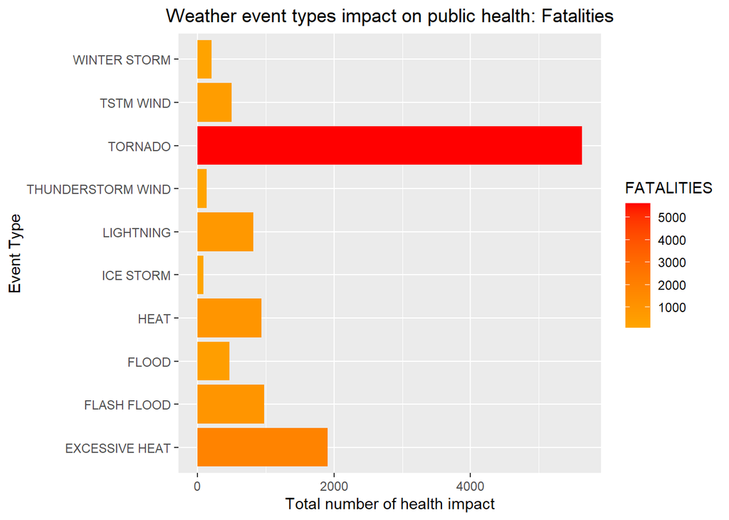

```r
# transform EVETYPE to factor variable for health variables
stormHealth_Top10$EVTYPE <- as.factor(stormHealth_Top10$EVTYPE)

# plot FATALITIES by EVENTYPE
g<-ggplot(data=stormHealth_Top10, aes(x=EVTYPE, y=FATALITIES, fill=FATALITIES))

g + geom_bar(stat = "identity")+ scale_fill_gradient(low = "orange", high = "red") + coord_flip() +   xlab("Event Type") +   ylab("Total number of health impact") + ggtitle("Weather event types impact on public health: Fatalities") + theme(plot.title = element_text(hjust = 0.5))
```

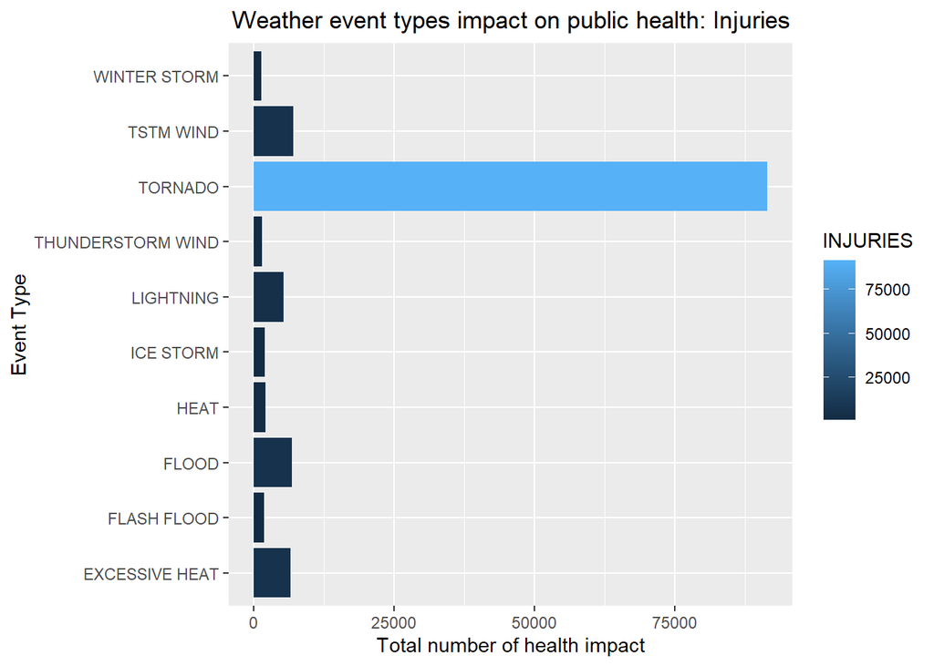

```r
# plot InJURIES by EVENTYPE

g2<-ggplot(data=stormHealth_Top10, aes(x=EVTYPE, y=INJURIES, fill=INJURIES ))

g2 + geom_bar(stat = "identity") + coord_flip() +   xlab("Event Type") +   ylab("Total number of health impact") + ggtitle("Weather event types impact on public health: Injuries") + theme(plot.title = element_text(hjust = 0.5))
```

```r
#print(g)
```

Tornados are the worst events causing the most impacts on Public Health.

### Question 2 Economic impact

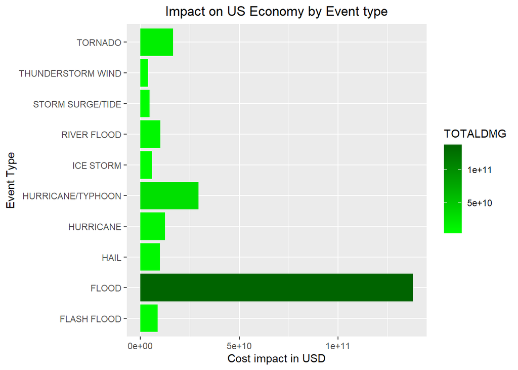

```r
# transform EVETYPE to factor variable for economic variables
stormdamage_total$EVTYPE <- as.factor(stormdamage_total$EVTYPE)

# plot 10 highest economic disasters
g3<-ggplot(data=stormdamage_total, aes(x=EVTYPE, y=TOTALDMG, fill=TOTALDMG))

g3 + geom_bar(stat = "identity")+ scale_fill_gradient(low = "green", high = "dark green") + coord_flip() +   xlab("Event Type") +   ylab("Cost impact in USD") + ggtitle("Impact on US Economy by Event type") + theme(plot.title = element_text(hjust = 0.5))
```

Floods have the main impact in US economy costing the highest amount of USD dollars.